# ECE 5470 Lab 9 Report

##### B. Dice training and balancing

#### Convnet Balancing with Focal Loss

Discussion:

1. Hyperparameter tuning: It involves gamma and alpha parameters. SInce we didn't iterate for these parameters, the effectivness of the focal loss is sensitive to these hyperparameters. Thereofre, proper tuning is required.
2. The nature of the dataset also depends on the result. Since the data is randomly created with different backgrounds and color ranges of the backgrounds and the colours of the characters, there is a possibility that the focal loss is not able to train on all the different types of imbalanes and improve the DICE score.

We can try different combinations of loss functions and tune the hyperparameters to achieve higher DICE score.

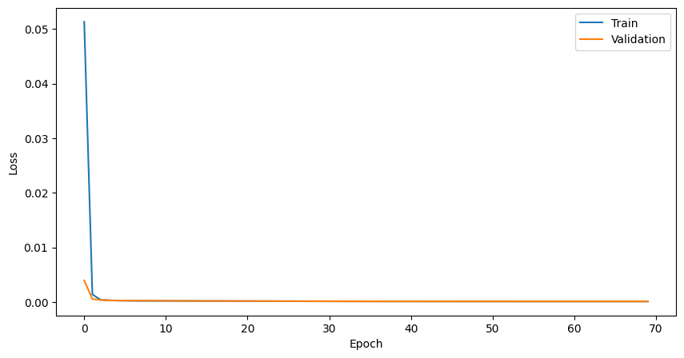

[output not shown]

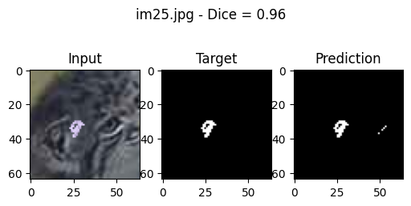

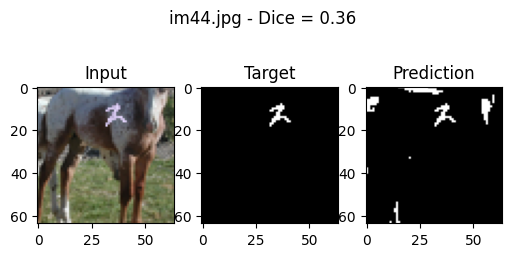

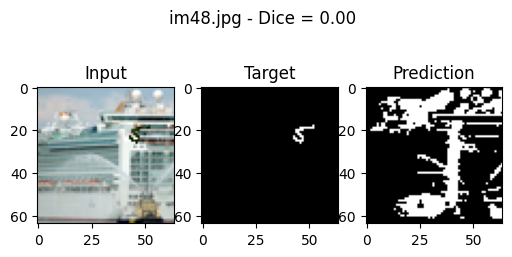

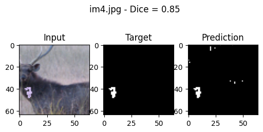

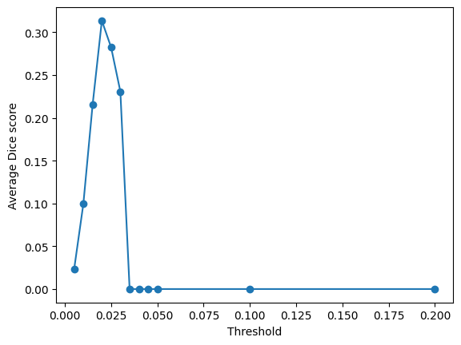

```python
vd.dispvx('A2_convnet1_focal_loss.png',capt='Loss for 50 epochs')
vd.dispvx('A2_convnet1_focal_img1.png')
vd.dispvx('A2_convnet1_focal_img2.png')
vd.dispvx('A2_convnet1_focal_img3.png')
vd.dispvx('A2_convnet1_focal_img4.png')
vd.dispvx('A2_convnet1_focal_dice.png')
```

#### Unet2 Balancing with Focal Loss

Discussion:

1. Hyperparameter tuning: It involves gamma and alpha parameters. SInce we didn't iterate for these parameters, the effectivness of the focal loss is sensitive to these hyperparameters. Thereofre, proper tuning is required.
2. The nature of the dataset also depends on the result. Since the data is randomly created with different backgrounds and color ranges of the backgrounds and the colours of the characters, there is a possibility that the focal loss is not able to train on all the different types of imbalanes and improve the DICE score.

We can try different combinations of loss functions and tune the hyperparameters to achieve higher DICE score.

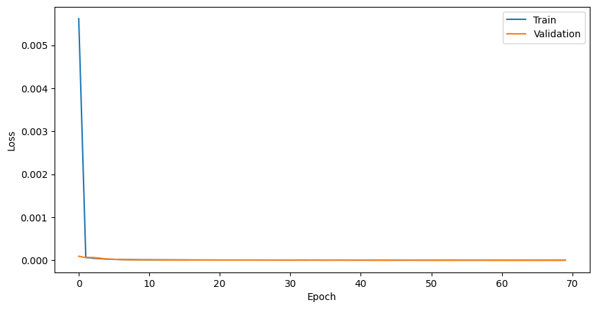

[output not shown]

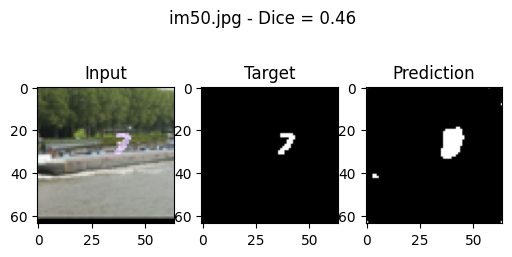

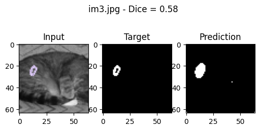

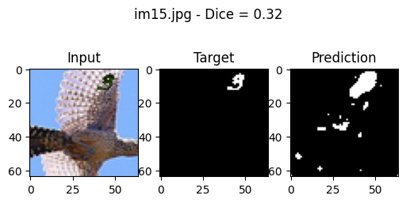

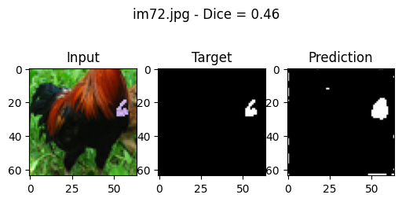

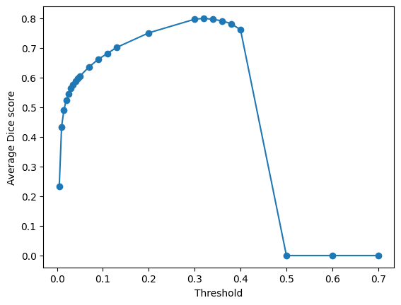

```python
vd.dispvx('A2_unet2_focal_loss.png',capt='Loss for 50 epochs')
vd.dispvx('A2_unet2_focal_img1.png')
vd.dispvx('A2_unet2_focal_img2.png')
vd.dispvx('A2_unet2_focal_img3.png')
vd.dispvx('A2_unet2_focal_img4.png')
vd.dispvx('A2_unet2_focal_dice.png')
```

## A.3. New Model Design

Modify the tutorial pytorch models to achieve better results.

```python
# RCNN convnet1
class convnet1(nn.Module):
    def __init__(self, in_ch=3, n_channels=8):
        super(convnet1, self).__init__()
        self.activation = F.relu
#=========================================================================
#Changes in kernelz size and padding for convnet1
        self.conv1 = nn.Conv2d(in_ch, n_channels, kernel_size= 3, padding=1)
        self.conv2 = nn.Conv2d(n_channels, 1, kernel_size= 3, padding=1)

    def forward(self, x):
        out = self.conv1(x)
        out = self.activation(out)
        out = self.conv2(out)

        return out

## Unet1
class unet1(nn.Module):
    def __init__(self, in_ch=3, n_channels=8):
        super(unet1, self).__init__()
        self.activation = F.relu

        self.down1 = down_block(in_ch, n_channels)

        self.bridge = down_block(in_ch=n_channels, out_ch=n_channels*2, max_pooling=False)

        self.up1 = up_block(in_ch=n_channels*2, out_ch=n_channels)
        self.final_conv = nn.Conv2d(n_channels, 1, kernel_size= 1, padding=0)

    def forward(self, x):
        out, skip1 = self.down1(x)
        out, _ = self.bridge(out)

        out = self.up1(out, skip1)
        out = self.final_conv(out)

        return out

## Unet2
class unet2(nn.Module):
    def __init__(self, in_ch=3, n_channels=8):
        super(unet2, self).__init__()

        self.down1 = down_block(in_ch, n_channels)
        self.down2 = down_block(in_ch=n_channels, out_ch=n_channels*2)

        self.bridge= down_block(in_ch=n_channels*2, out_ch=n_channels*4, max_pooling=False)

        self.up1 = up_block(in_ch=n_channels*4, out_ch=n_channels*2)
        self.up2 = up_block(in_ch=n_channels*2, out_ch=n_channels)
#===================================================================
#changes in kernel size and padding of unet2
        self.final_conv = nn.Conv2d(n_channels, 1, kernel_size= 3, padding=1)

    def forward(self, x):
        out, skip1 = self.down1(x)
        out, skip2 = self.down2(out)

        out, _ = self.bridge(out)

        out = self.up1(out, skip2)
        out = self.up2(out, skip1)
        out = self.final_conv(out)

        return out


class down_block(nn.Module):
    def __init__(self, in_ch, out_ch, kernel_size=3, dropout_prob=0, max_pooling=True):
        super(down_block, self).__init__()

        self.dropout_prob = dropout_prob
        self.max_pooling = max_pooling

        self.conv = nn.Conv2d(in_ch, out_ch, kernel_size=kernel_size, padding=1)
        self.bn = nn.BatchNorm2d(out_ch)
        self.activation = F.relu

        # if dropout_prob > 0 add a dropout layer, with the variable dropout_prob as parameter
        if dropout_prob > 0:
            self.dropout = nn.Dropout2d(p=dropout_prob)

        # if max_pooling is True add a MaxPooling2D with 2x2 pool_size
        if max_pooling:
            self.maxpool = nn.MaxPool2d(2)

    def forward(self, inputs):
        conv = self.conv(inputs)
        conv = self.bn(conv)
        conv = self.activation(conv)

        if self.dropout_prob > 0:
            conv = self.dropout(conv)

        next_layer = conv
        skip_connection = conv

        if self.max_pooling:
            next_layer = self.maxpool(conv)

        return next_layer, skip_connection

class up_block(nn.Module):
    def __init__(self, in_ch, out_ch, kernel_size=3):
        super(up_block, self).__init__()

        self.up = nn.ConvTranspose2d(in_ch, out_ch, kernel_size=2, stride=2)
        self.conv = nn.Conv2d(in_ch, out_ch, kernel_size=kernel_size, padding=1)
        self.bn = nn.BatchNorm2d(out_ch)
        self.activation = F.relu

    def forward(self, expansive_input, contractive_input=None):
        up = self.up(expansive_input)

        merge = torch.cat([up, contractive_input], axis=1)

        out = self.conv(merge)
        out = self.bn(out)
        out = self.activation(out)
        return out
```

Discuss any achieved performance improvement. List the changes you have made.

##### 1. convnet1 with 3x3

Discussion:

To make apple to apple comparison we kept the same 50 epochs and changed the kernel size to 3 and padding of 1. We trained the model with the same loss function and got better results. The highest DICE score we achieved was 0.66 at a threshold of 0.12 which is higher than the DICE score we got in task A1 (0.53). This shows us that by increasing the kernel size the model is more sensitive to the details within the image dataset and since the weights are also increased due to increase in kernez size, the parameters also increase which contributes to better training accuracy and perofmrance on test data set.

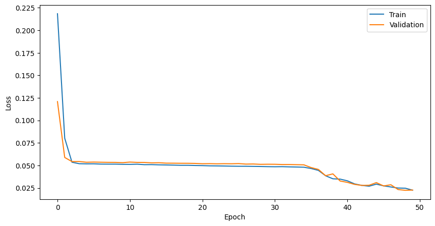

```
Loss for 50 epochs
```

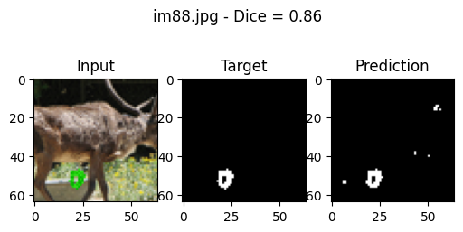

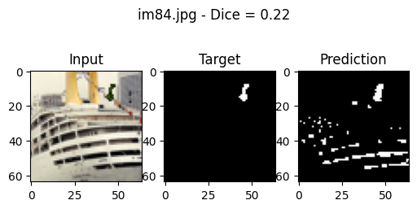

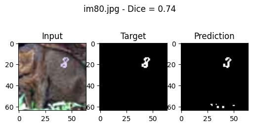

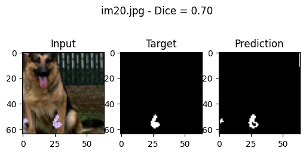

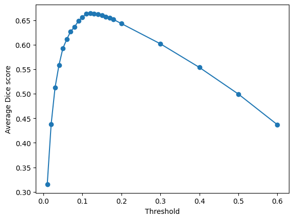

```python
vd.dispvx('A3_convnet_loss.png',capt='Loss for 50 epochs')
vd.dispvx('A3_convnet_img1.png')
vd.dispvx('A3_convnet_img2.png')
vd.dispvx('A3_convnet_img3.png')
vd.dispvx('A3_convnet_img4.png')
vd.dispvx('A3_convnet_dice.png')
```

##### 2. unet2 with 3x3

Discussion:

At the same time, when we tried with higher kernel size and padding in unet2 we got a DICE score of 0.95 which is very close to the DICE score of 0.96 in the first task without any changes to the model. This tells us that the DICE score is relatively constant but it increases the computation required to train the model without substantially increasing the DICE score. There is also a chance of overfitting. SInce the kernel size is increased, and our dataset is very small comparitively, there are chances that it overfit to the training set and hence didn't perform as good on the test data set. Therefore, we can say that increasing the kernel size and padding does not always guarantee a better result.

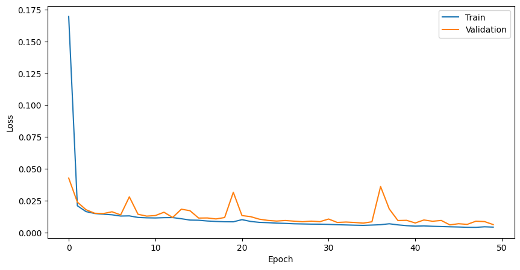

```
Loss for 50 epochs
```

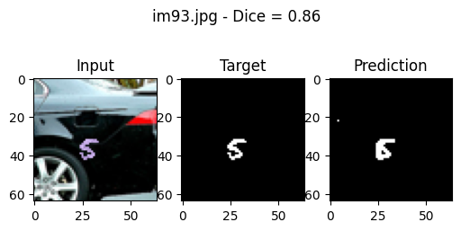

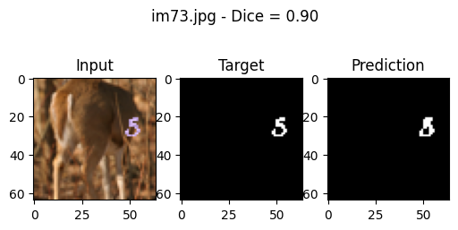

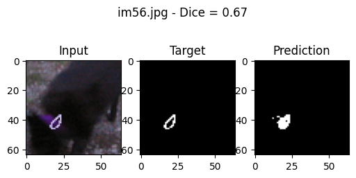

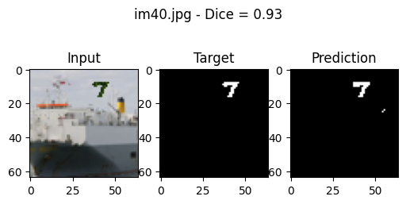

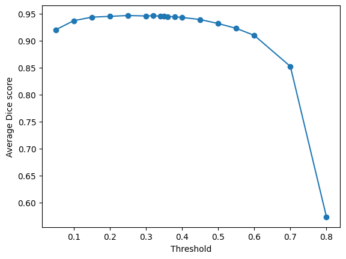

```python
vd.dispvx('A3_unet2_loss.png',capt='Loss for 50 epochs')
vd.dispvx('A3_unet2_img1.png')
vd.dispvx('A3_unet2_img2.png')
vd.dispvx('A3_unet2_img3.png')
vd.dispvx('A3_unet2_img4.png')
vd.dispvx('A3_unet2_dice.png')
```

## A.4. Summary

### Comparison of approaches

[output not shown]

### Discusssion

Make at least three significant observations from the above table

#### 1. Unet compared to convnet performed signficantly better in all cases in this lab. The DICE score achieved in unet models were substantially higher than the convnet models and this is possibly because of the structure of unet. Since unet uses skip connections, it takes into account the intermediate features or low level features from the initial convolutions and the high level features such as the initial inputs in intermediate convolution procedures. Moreover, since in Unet structure, the expansion of the image occurs to decode, the decoding helps to retain small details in spatial domain within the image data.

#### 2. In our lab tasks, we applied Dice Loss and Focal Loss to convnet1 and unet2. DICE Loss got us a higher DICE score for both the models compared to BCE Logits Loss, however, the Combo and Focal Loss got us lower DICE scores and even lower with Combo loss. This observation is possible because FOcal Loss particularly works on imbalanced data which in this case should have been effective but at the same time, the dataset is also complexed in terms of the spatial characteristics since there is very low uniformity in the color of the digits/target characters and the backgrounds as well since they are varying with each image and DICE Loss is more useful since it considers the spatial details to determine overlap between images. Therefore, although the Focal Loss is well suited for data imbalance but it does not have key focus on the spatial domain unlike DICE Loss which looks at the spatial information. Therefore, it is likely for this reason that the DICE Loss performed better than Focal Loss. Since focal loss weighs down images in the dataset that are easy to classify, it may have led to missing out signficant spatial information due to which the DICE score worsened by applying Focal Loss.

#### 3. When we make our model more complex like by increasing the kernel size or padding for CNN, it does not always guarantee a good result especially when the dataset is small. This is shown in our case in unet2 where it could not retrieve a better DICE score for us and this is primarily because the DICE was initially already high on test dataset. By further increasing the kernel size we didn't achieve higher DICE which is possibly because the data became overfit and this is also shown by the spikes in our validation loss curve shown above. This goes on to show that the model was possibly overfit primarily because more parameters are trained now and the dataset is considerably SMALL in this lab. More precise regularization can be done to achieve a higher DICE score in this model to further avoid overfitting.